# MoBPS (1.13.15)

Torsten Pook

2026-02-18

This file descripts all updates of the software since 1.13.07

## MiXBLUP

DGV-PBLUP in MiXBLUP now automatically detects which SNPs were used in the previous evaluation and therefore does not require setting mixblup.maf = 0 and generating arrays for the evaluation

Parameter startval_check to check input for !RESTART has been added through mixblup.startval_check in breeding.diploid()

Its now possible to set a directory for the generation of temporary files from MiXBLUP through mixblup.tmpdir in breeding.diploid()

## Variance component estimation

Variance from the previous breeding value estimation are now stored within the population-list. Set bve.vc.last in breeding.diploid() to TRUE to use these VCs in the current evaluation (by automatically setting sigma.g / sigma.e / mixblup.residual.cov / mixblup.genetic.cov).

Future plans: Added VC estimation through ASReml and make it possible that MoBPS-internal estimation of variance components (bve.varcomp.gen/database/cohort) can include individuals not included in the breeding value estimation.

### creating.diploid()

#### Correlated traits

MoBPS approach to generate correlation between traits assumes that uncorrelated traits can be generated first (see Chapter 15 Guidelines). For non-additive traits this is not always straightforward. An additional whitening step was added so that any correlation should be corrected for. For purely additive traits this is not needed (but also does not harm). Detailed description of the Method will follow soon in Chapter 15.

```r
library(MoBPS)

population = creating.diploid(nsnp = 10000, nindi = 100,
                              n.overdominant = c(500,500),
                              qtl.position.shared = TRUE,
                              trait.cor = matrix(c(1,0.5,
                                                 0.5,1), ncol = 2),
                              verbose = FALSE)

# different trait have overdominant QTL on the same locations --> correlation will be too high
print(cor(t(get.bv(population, gen = 1))))
```

```
##           Trait 1   Trait 2
## Trait 1 1.0000000 0.8604146
## Trait 2 0.8604146 1.0000000
```

```r
# include whitening
population = creating.diploid(nsnp = 10000, nindi = 100,
                              n.overdominant = c(500,500),
                              qtl.position.shared = TRUE,
                              whitening = TRUE,
                              trait.cor = matrix(c(1,0.5,
                                                 0.5,1), ncol = 2),
                              verbose = FALSE)

print(cor(t(get.bv(population, gen = 1))))
```

```
##         Trait 1 Trait 2
## Trait 1     1.0     0.5
## Trait 2     0.5     1.0
```

#### Markovian coalesant simulator

creating.diploid now allows for the generation of founder genotypes through a Markovian coalesant simulator for more realistic population structure when no real genotypes are available. This requires the R-package AlphaSimR. The output of MACS will be modified to obtain the target minor allele frequency spectrum (default: uniform) unless this is deactived (macs.freq.correction = FALSE). This is also available in founder.simulation().

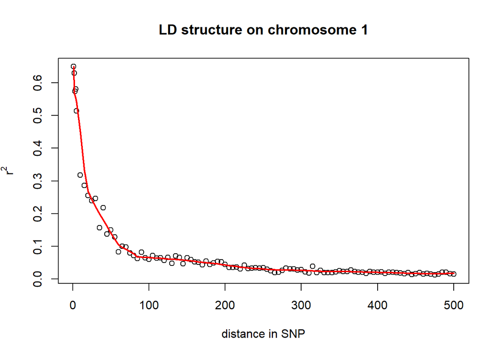

```r
library(MoBPS)

population = creating.diploid(nsnp = 10000, nindi = 250, chr.nr = 3,
                              dataset = "macs",
                              macs.ne = 100,
                              verbose = FALSE)

ld.decay(population, gen = 1, plot = TRUE)
```

#### QTL allele frequencies

Allele frequency distribution of QTLs can now independently controlled through qtl.beta.shape1 and qtl.beta.shape2 if they are generated through the qtl parameter.

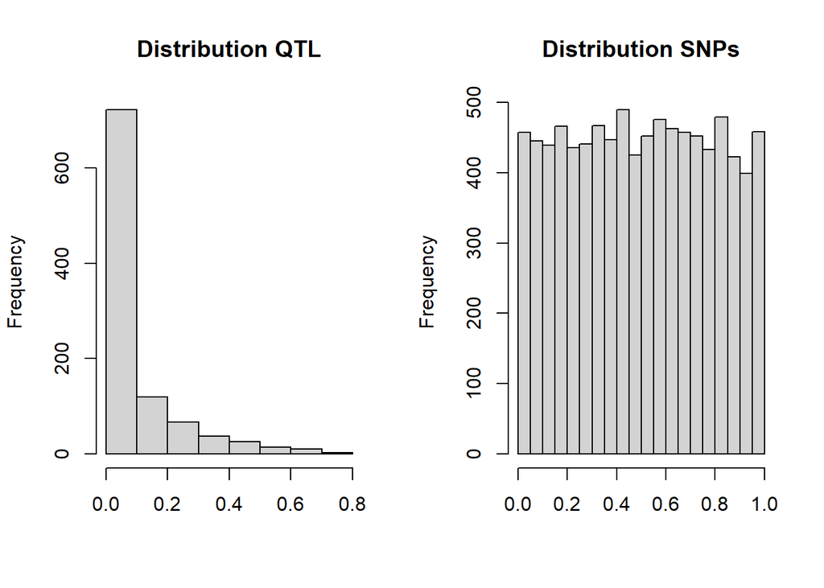

```r
library(MoBPS)

population = creating.diploid(nsnp = 10000, nindi = 250, chr.nr = 3,
                              nqtl = 1000,
                              n.additive = 1000,
                              qtl.beta.shape1 = 0.3,
                              qtl.beta.shape2 = 3)

par(mfrow = c(1,2))
hist(rowMeans(get.geno(population, gen = 1)[get.qtl(population),])/2, main = "Distribution QTL", xlab = "")
hist(rowMeans(get.geno(population, gen = 1)[-get.qtl(population),])/2, main = "Distribution SNPs", xlab = "")
```

### breeding.diploid()

#### Variance components ((See major updates))

#### Removing phenotypes

Added feature in breeding.diploid() to more conveniently remove phenotypes (in addition to the existing genotyped.remove.gen/database/cohorts)

```r
library(MoBPS)

population = creating.diploid(nsnp = 1000, nindi = 20, n.additive = 100,
                              verbose = FALSE)

population = breeding.diploid(population, phenotyping.gen = 1,
                              verbose = FALSE)

# remove phenotypes of males
population = breeding.diploid(population, phenotyping.remove.database = cbind(1,1),
                              verbose = FALSE)

get.pheno(population, gen = 1)
```

```
##          1  2  3  4  5  6  7  8  9 10       11      12       13       14
## Trait 1 NA NA NA NA NA NA NA NA NA NA 84.13392 90.8564 88.19258 95.42647
##               15      16       17       18       19      20
## Trait 1 97.75884 108.966 120.8188 111.9265 90.41868 102.693
```

### get.database() - ID handling

```r
library(MoBPS)

population = creating.diploid(nsnp = 10000, nindi = 100,
                              verbose = FALSE)
population = breeding.diploid(population, copy.individual.m = TRUE,
                              selection.m.database = cbind(1,1),
                              verbose = FALSE)
```

```
## Modify breeding size to be in-line with selection size.
```

```r
# individuals in generation 2 are a copy of gen 1
get.database(population, gen = 1:2, id.first = TRUE)
```

```
##      [,1] [,2] [,3] [,4]
## [1,]    1    1    1   50
## [2,]    1    2    1   50
```

```r
get.database(population, gen = 1:2, id.last = TRUE)
```

```
##      [,1] [,2] [,3] [,4]
## [1,]    1    2    1   50
## [2,]    2    1    1   50
```

```r
# this will only search within gen/database/cohort (hence this does not report on gen2 location)
get.database(population, gen = 1, id.last = TRUE)
```

```
##          start end
## [1,] 1 1     1  50
## [2,] 1 2     1  50
```

```r
# check where else individuals from gen 1 are stored
get.database(population, gen = 1, id.all.copy = TRUE)
```

```
##      [,1] [,2] [,3] [,4]
## [1,]    1    1    1   50
## [2,]    1    2    1   50
## [3,]    2    1    1   50
```

### add.array() - Overwriting

add.array() now overwrites an existing array if another array with the same name was previously generated.

```r
library(MoBPS)

population = creating.diploid(nsnp = 1000, nindi = 100,
                              verbose = FALSE)

array_snps = rep(FALSE, 1000)
array_snps[sample(1000,100)] = TRUE

population = add.array(population, marker.included = array_snps, array.name = "Subset")

# new larger array

array_snps = rep(FALSE, 1000)
array_snps[sample(1000,250)] = TRUE

population = add.array(population, marker.included = array_snps, array.name = "Subset")
```

```
## Array name has been previously used. Replace array with the new marker panel.
```